# Part II - (FordGoBike Key Findings Presentation)

## by (Jerome Gameli Kofi Davor)

## Investigation Overview

- In my first key presentation I will focus on service usage difference between customers and subscribers. I will also show how age group population and days of the week comes into play.
- My second key presentation would be about user types by distance and whether age group affects users distance.
- My third key presentation insight provides more information about age groups and how distance and speed affects them.

## Dataset Overview

The dataset contains:

- An id for each bicycle
- The trip duration in seconds
- Start time for the trip
- End time for the trip
- The id of the station where the trip started
- The name of the station where the trip started
- The latatitude of the start station
- The longitude of the start station
- The id of the station where the trip ended
- The name of the station where the trip ended
- The latatitude of the end station
- The longitude of the end station
- The users of the GoFord bike service (classified into customers and subscribers)
- The users' birth year
- The users' gender (classified into male, female and others)

**Feature Engineering of dataset**: This was carried out to further derive valuable information from the orignal dataset. They include:

- Trip duration in minutes
- Trip duration in hours
- From users' birth year, users' age were determined
- Month the trip took place
- Days of the week
- Distance travelled in kilometer
- Speed in km/hr
- Age group (classified into young adults, middle aged adults, seniors)

## (Visualization 1)

- Ride service usage difference between ride user types; customers and subscribers.

  This visualization shows how the users of GoFord Bike service are classified based on user type.

```
This shows that subcribers use the ride service way more than customers by a ratio of 91% : 9%
```

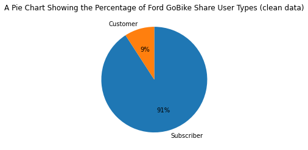

## (Visualization 2)

- user type vs distance: Does age group determine why customers or users cover a long distance.

  The charts show that age group cannot determine why customers or users cover a long distance.

[output not shown]

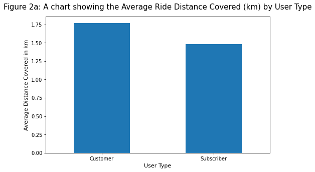

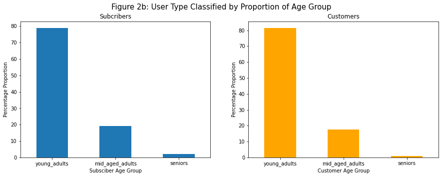

```
The chart shows that young adults have a higher percentage proportion than other age groups for both user types.
 With subscribers having a higher amount of seniors than customers
```

```
 As figure 2a shows average Ride Distance covered (km) by User Type.
 Figure 2b shows the user type category being broken down into age groups.
 Figure 2c shows the speed of age groups.

 Relating figure 2c to figure 2b & 2a above; with young adults having a larger population and the highest average speed,this does not have an effect on customers' average distance travelled.

 Since speed is relative, in this case, to distance. Speed is a good way to measure distance travelled and also to determine if age groups can determine customers' longer distance.
```

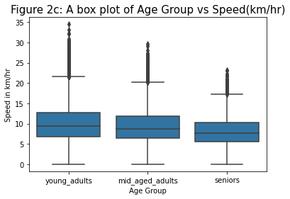

## (Visualization 3)

```
Conclusion: The chart clearly shows that young adults are more likely to travel longer distances at a faster speed but it shows no evidence on how this affected customers distance
```

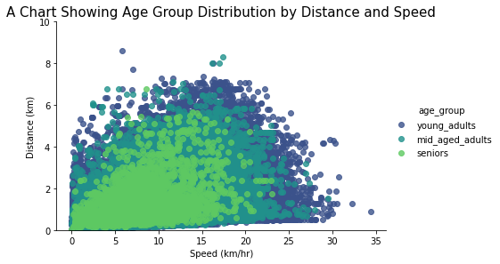